# Probabilistic Programming for Sports Analytics

## Bayesian Data Analysis Meetup • April 18, 2019 • New York City

## [@AustinRochford](https://twitter.com/AustinRochford)

## About Me

[figure not shown]

### Chief Data Scientist @ [Monetate](http://www.monetate.com/) • PyMC3 contributor

### [@AustinRochford](https://twitter.com/AustinRochford) • austinrochford.com • github.com/AustinRochford

### arochford@monetate.com • austin.rochford@gmail.com

## About Monetate

- Founded 2008, web optimization and personalization SaaS
- Observed 5B impressions and $4.1B in revenue during Cyber Week 2017

[figure not shown]

monetate.com/about/careers

## Agenda

- Sports analytics
  - Heuristics and uncertainty
- First steps
  - Batting average
  - Save percentage
- NBA foul calls
- Future work

# Sports Analytics

[figure not shown]

## Heuristics and Uncertainty

> The basic blueprint for predicting a player’s upcoming season from his past is the Marcel method, introduced by prominent baseball and hockey analyst Tom Tango back in 2005. It’s a three-step process that
> 1. starts with a weighted average of a player’s three most recent seasons;
> 2. regresses that player’s performance toward the league mean, based on games played (we’ll explain why and how in a moment); and
> 3. applies an age adjustment to account for developing rookies and declining veterans. With regard to the first step, Tango proposes a weighting of 5-4-3, while I prefer a 4-2-1 approach that assumes that every season’s data has twice the predictive power as the season previous.

Vollman, Rob, Awad, Tom, Fyffe, Iain. *Hockey Abstract Presents* Stat Shot. ECW Press. Kindle Edition.

[figure not shown]

[Bayesian Bagging to Generate Uncertainty Intervals: A Catcher Framing Story](https://www.baseballprospectus.com/news/article/38289/bayesian-bagging-generate-uncertainty-intervals-catcher-framing-story/)

# First Steps

## Batting Average

```python
mlb_df = load_data(get_data_url('2018_batting.csv'), 'Name', ['AB', 'H'])
```

```python
mlb_df.head()
```

| player_id | name | ab | h |
| --- | --- | --- | --- |
| abreujo02 | Jose Abreu | 499 | 132 |
| acunaro01 | Ronald Acuna | 433 | 127 |
| adamewi01 | Willy Adames | 288 | 80 |
| adamja01 | Jason Adam | 0 | 0 |
| adamsau02 | Austin L. Adams | 0 | 0 |

```python
def hierarchical_normal(name, shape, μ=None):
    if μ is None:
        μ = pm.Normal(f"μ_{name}", 0., 5.)

    Δ = pm.Normal(f"Δ_{name}", shape=shape)
    σ = pm.HalfNormal(f"σ_{name}", 2.5)

    return pm.Deterministic(name, μ + Δ * σ)
```

```python
with pm.Model() as mlb_model:
    η = hierarchical_normal("η", n_player)
    ba = pm.Deterministic("ba", pm.math.sigmoid(η))

    hits = pm.Binomial("hits", batter_df['ab'], ba, observed=batter_df['h'])
```

```python
with mlb_model:
    mlb_trace = pm.sample(**SAMPLE_KWARGS)
```

```
Auto-assigning NUTS sampler...
Initializing NUTS using jitter+adapt_diag...
Multiprocess sampling (3 chains in 3 jobs)
NUTS: [σ_η, Δ_η, μ_η]
```

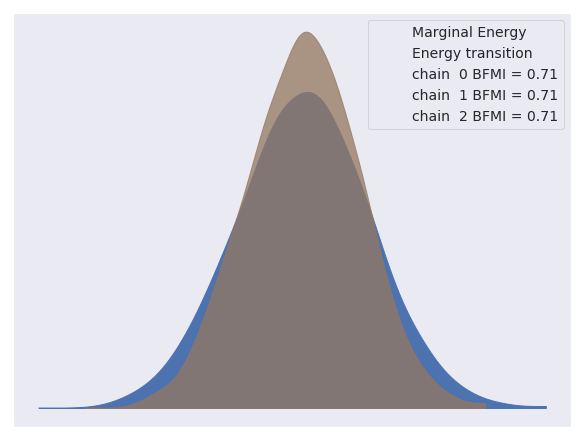

```python
az.plot_energy(mlb_trace);
```

```python
(az.rhat(mlb_trace).max().to_array().max())
```

```
<xarray.DataArray ()>
array(1.01)
```

### Mike Trout

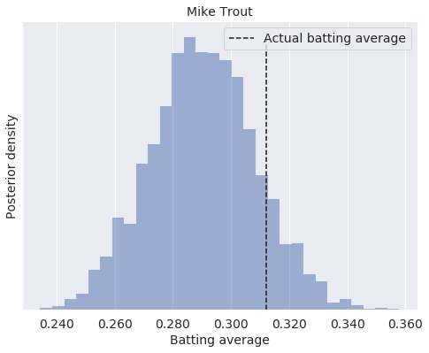

```python
fig
```

### Mike Trout vs. Bryce Harper

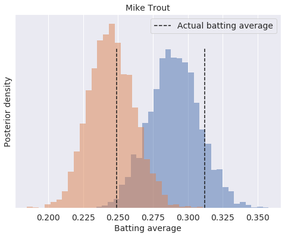

```python
fig
```

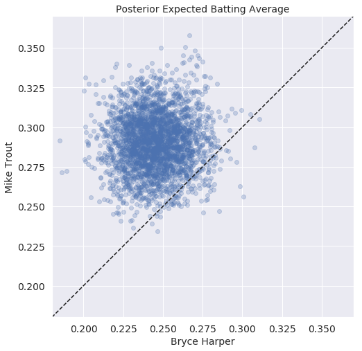

```python
fig
```

```python
(mlb_trace['ba'][:, harper_ix] < mlb_trace['ba'][:, trout_ix]).mean()
```

```
0.96666666666666667
```

### Bryce Harper vs. Rhys Hoskins

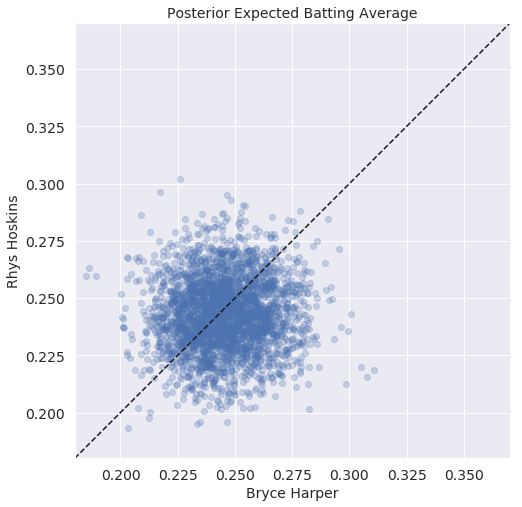

```python
fig
```

```python
(mlb_trace['ba'][:, harper_ix] < mlb_trace['ba'][:, hoskins_ix]).mean()
```

```
0.45700000000000002
```

### Uncertainty in batting average

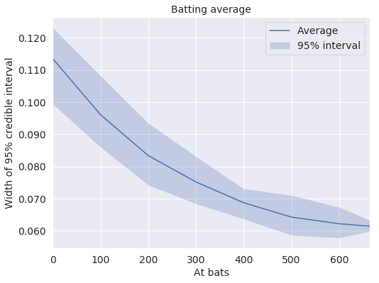

```python
ax.figure
```

## Save Percentage

```python
nhl_df = load_data(get_data_url('2017_2018_goalies.csv'), 'Player', ['SA', 'SV'])
```

```python
nhl_df.head()
```

| player_id | name | sa | sv |
| --- | --- | --- | --- |
| allenja01 | Jake Allen | 1614 | 1462 |
| andercr01 | Craig Anderson | 1768 | 1588 |
| anderfr01 | Frederik Andersen | 2211 | 2029 |
| appleke01 | Ken Appleby | 55 | 52 |
| bernijo01 | Jonathan Bernier | 1092 | 997 |

```python
with pm.Model() as nhl_model:
    η = hierarchical_normal("η", n_goalie)
    svp = pm.Deterministic("svp", pm.math.sigmoid(η))

    saves = pm.Binomial("saves", nhl_df['sa'], svp, observed=nhl_df['sv'])
```

```python
with nhl_model:
    nhl_trace = pm.sample(nuts_kwargs={'target_accept': 0.9}, **SAMPLE_KWARGS)
```

```
Auto-assigning NUTS sampler...
Initializing NUTS using jitter+adapt_diag...
Multiprocess sampling (3 chains in 3 jobs)
NUTS: [σ_η, Δ_η, μ_η]
```

### Sergei Bobrovsky

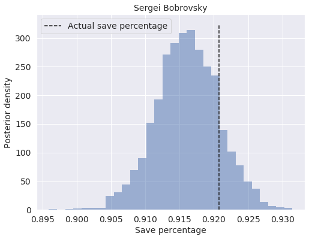

```python
fig
```

### Uncertainty in save percentage

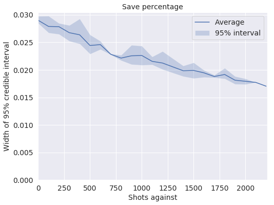

```python
ax.figure
```